# QuaDramA Report: Miß Sara Sampson

# Meta data

- Author(s): [Lessing, Gotthold Ephraim](http://d-nb.info/gnd/118572121)
- Acts: 5
- Scenes: 9, 8, 7, 9, 11

# Character Lists

## By Order of appearance

All figures, in the order they have their first appearance

```
##  [1] "SIR WILLIAM"  "WAITWELL"     "DER WIRT"     "MELLEFONT"
##  [5] "NORTON"       "BETTY"        "SARA"         "MARWOOD"
##  [9] "HANNAH"       "DER BEDIENTE" "ARABELLA"
```

# Overall Speech Distribution

## Bar chart

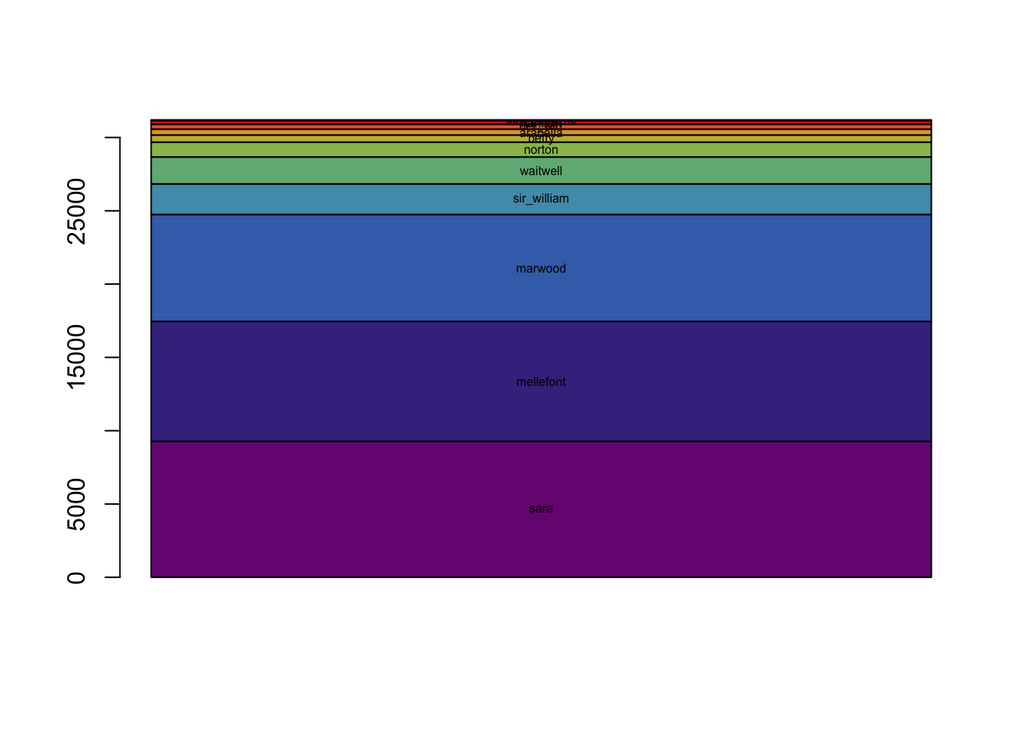

## Table

| corpus | drama | figure | length | tokens | types | utterances | utteranceLengthMean | utteranceLengthSd | firstBegin | lastEnd | figure_surface | Gender | Age |
| --- | --- | --- | --- | --- | --- | --- | --- | --- | --- | --- | --- | --- | --- |
| gdc | rjmw.0 | arabella | 31201 | 404 | 165 | 13 | 31.07692 | 31.73973 | 43987 | 52559 | ARABELLA | female | NA |
| gdc | rjmw.0 | betty | 31201 | 484 | 224 | 20 | 24.20000 | 36.81190 | 9014 | 156987 | BETTY | female | NA |
| gdc | rjmw.0 | der_bediente | 31201 | 44 | 34 | 2 | 22.00000 | 12.72792 | 31532 | 31790 | DER BEDIENTE | male | NA |
| gdc | rjmw.0 | der_wirt | 31201 | 327 | 179 | 7 | 46.71429 | 45.09514 | 3571 | 5695 | DER WIRT | male | NA |
| gdc | rjmw.0 | hannah | 31201 | 258 | 155 | 16 | 16.12500 | 15.65407 | 28392 | 58523 | HANNAH | female | NA |
| gdc | rjmw.0 | marwood | 31201 | 7295 | 1770 | 155 | 47.06452 | 62.37816 | 28320 | 141005 | MARWOOD | female | NA |
| gdc | rjmw.0 | mellefont | 31201 | 8176 | 1753 | 201 | 40.67662 | 51.01382 | 5848 | 170188 | MELLEFONT | male | NA |
| gdc | rjmw.0 | norton | 31201 | 1014 | 411 | 46 | 22.04348 | 23.44066 | 6328 | 170456 | NORTON | male | NA |
| gdc | rjmw.0 | sara | 31201 | 9278 | 1927 | 166 | 55.89157 | 79.16764 | 11766 | 167457 | SARA | female | NA |
| gdc | rjmw.0 | sir_william | 31201 | 2085 | 709 | 23 | 90.65217 | 108.89345 | 597 | 170838 | SIR WILLIAM | male | NA |
| gdc | rjmw.0 | waitwell | 31201 | 1836 | 571 | 41 | 44.78049 | 59.75890 | 670 | 158683 | WAITWELL | male | NA |

# Presence and Utterances

## All Utterances

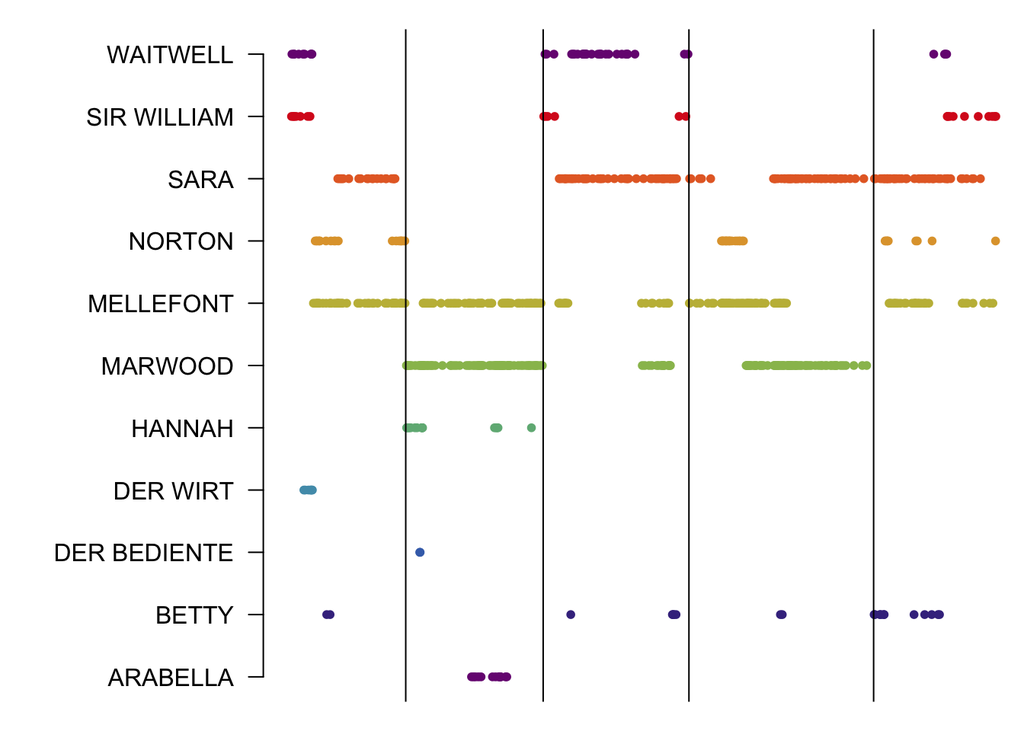

## Utterance Length Variation

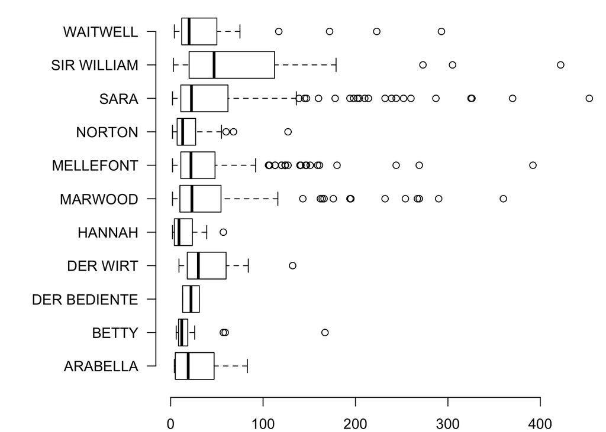

# Configuration and Copresence

## By Act

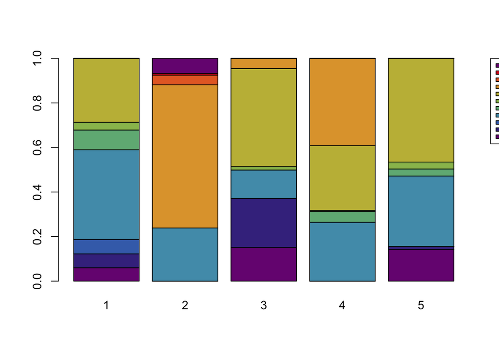

## By Scene

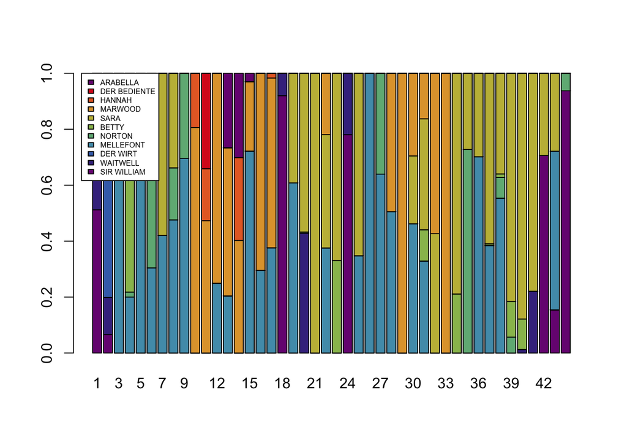

# Network Analysis

## Copresence Network

In a copresence network, two vertices are connected if the characters they represent appear together on stage (= are co-present on stage). The network shown here is based on scenes, i.e., the thicker an edge, the more scenes the two connected characters are copresent.

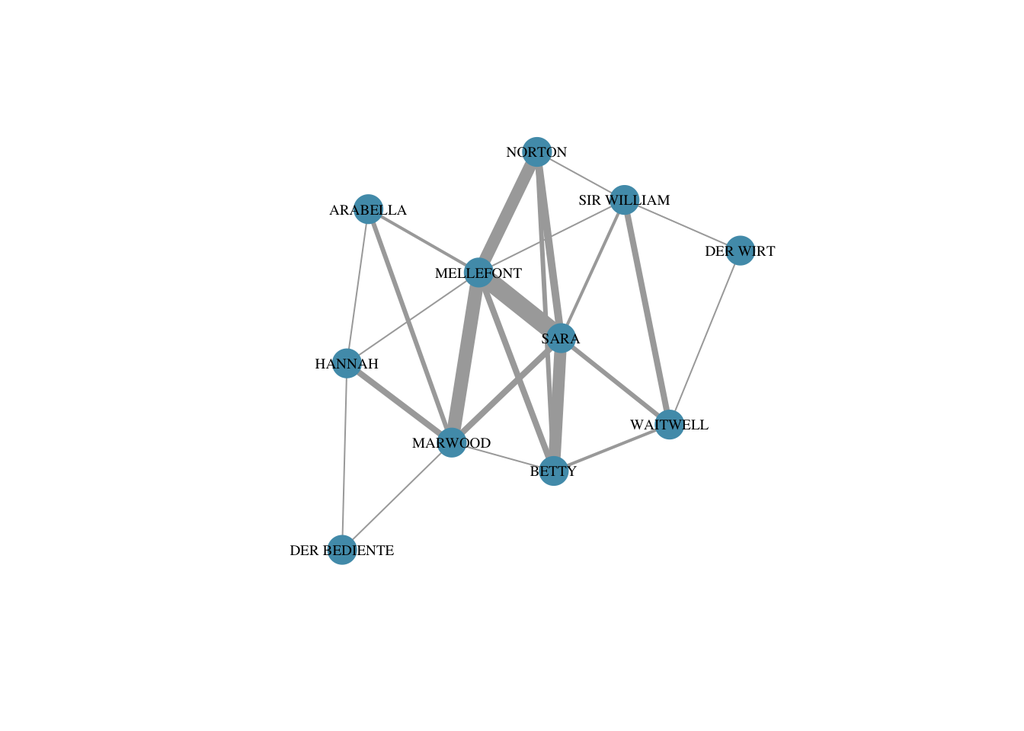

## Gossip Network

The “gossip network” represents character that talk about other characters. The colors don’t follow a particular pattern and are just added for readability. Edge thickness represent how often (number of scenes) this happens, and is scaled logarithmically. Currently, this includes scenes in which both characters are present. This will be changed later.

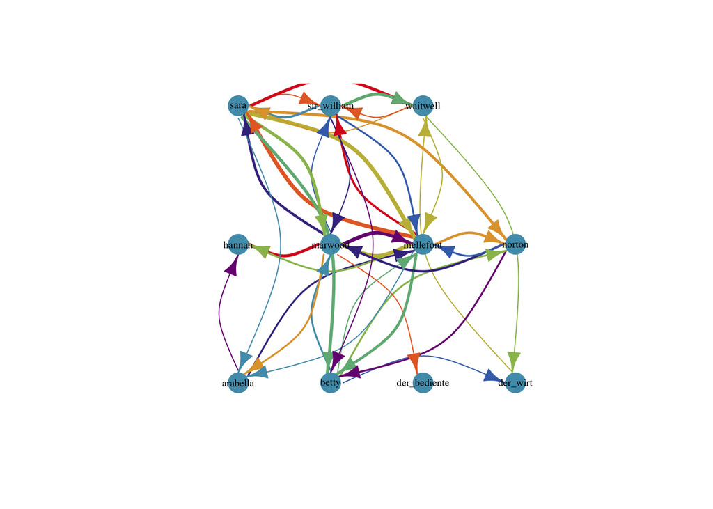

# Word Fields

## Bar Chart

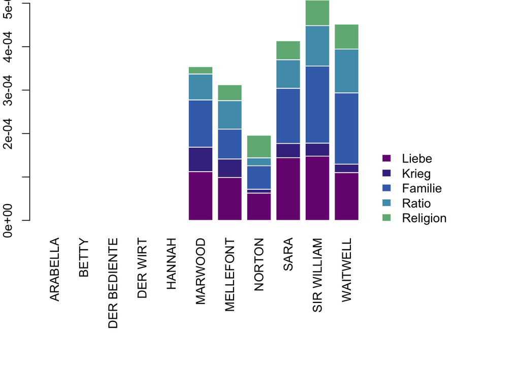

## Bar chart (z-scores)

[Z-scores in wikipedia](https://en.wikipedia.org/wiki/Standard_score)

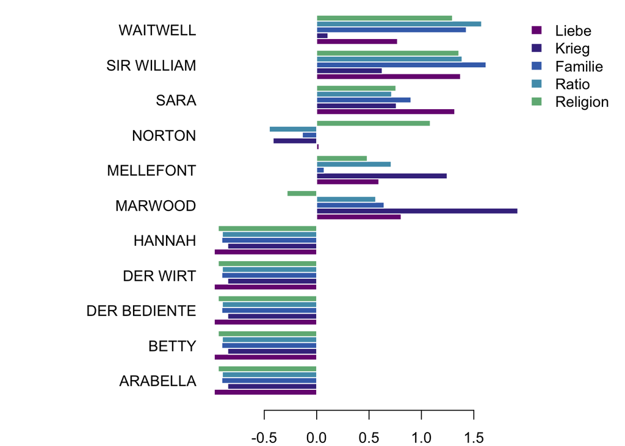

## Bar chart (scaled)

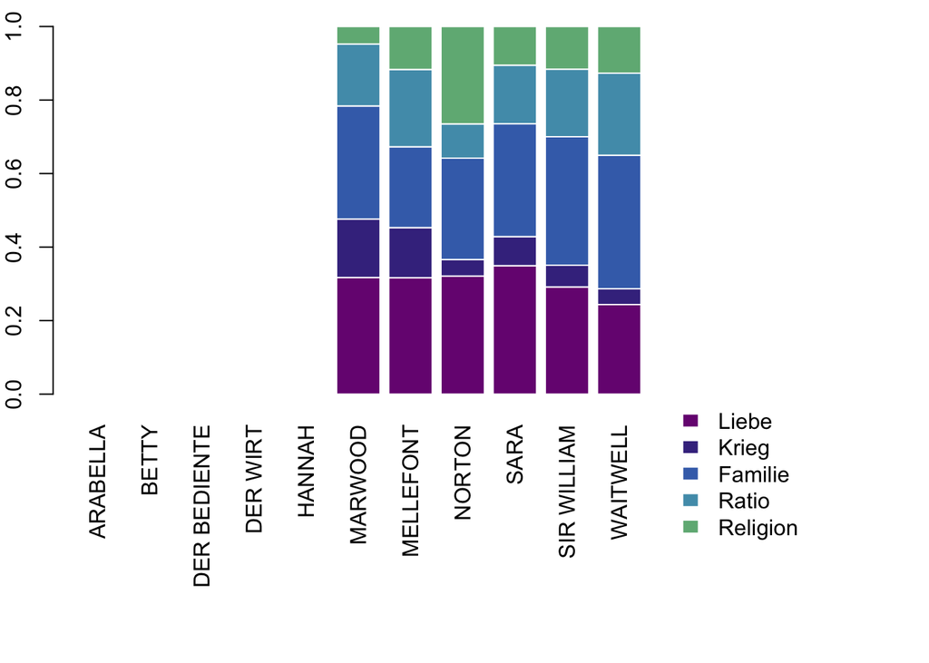

## Spider Web

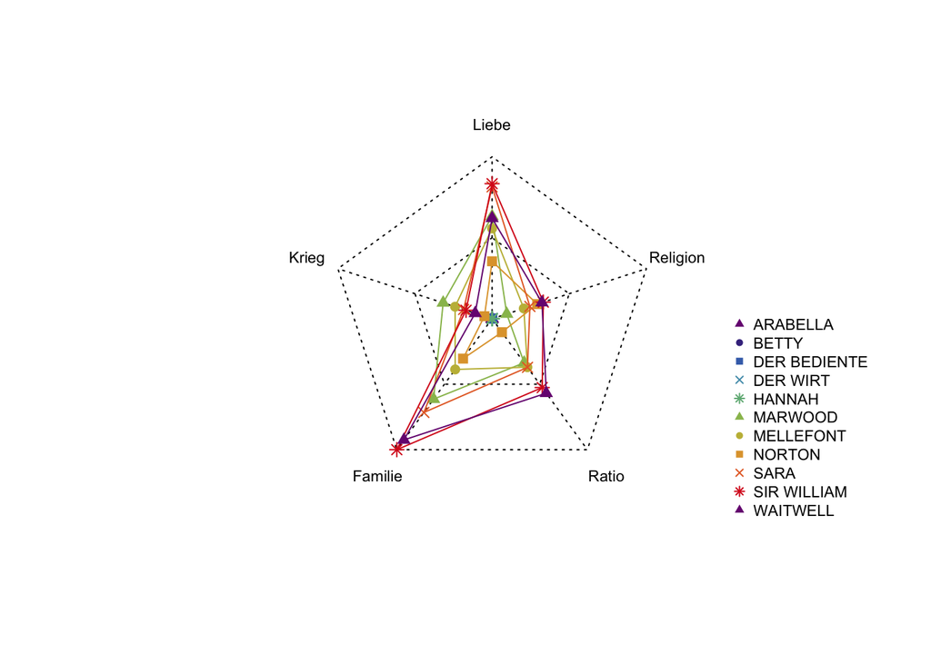

## Word fields

```
## $Liebe
##  [1] "adorieren"         "anbeten"           "Angebetete"
##  [4] "aufrichtig"        "Aufrichtigkeit"    "begehren"
##  [7] "Begierde"          "begieren"          "beweinen"
## [10] "Beziehung"         "brennen"           "Ceremonie"
## [13] "Copulation"        "copulieren"        "ehrlich"
## [16] "empfinden"         "Empfindsamkeit"    "Engel"
## [19] "Entzücken"         "fühlen"            "Funke"
## [22] "Gefühl"            "geliebt"           "Geliebte"
## [25] "Geliebter"         "Gemahl"            "Gemahlin"
## [28] "Glück"             "Heirat"            "Heirath"
## [31] "Herz"              "Herzen"            "Hochzeit"
## [34] "huldigen"          "kuscheln"          "Kuss"
## [37] "Kuß"               "küssen"            "Leidenschaft"
## [40] "Liebe"             "lieben"            "liebenswürdig"
```

[output cut: 144 more lines]

# Personnel Exchange

The following chart shows for each scene boundary the number of characters exchanged over the boundary. Different metrics have been proposd, the plot shows all of them in comparison.

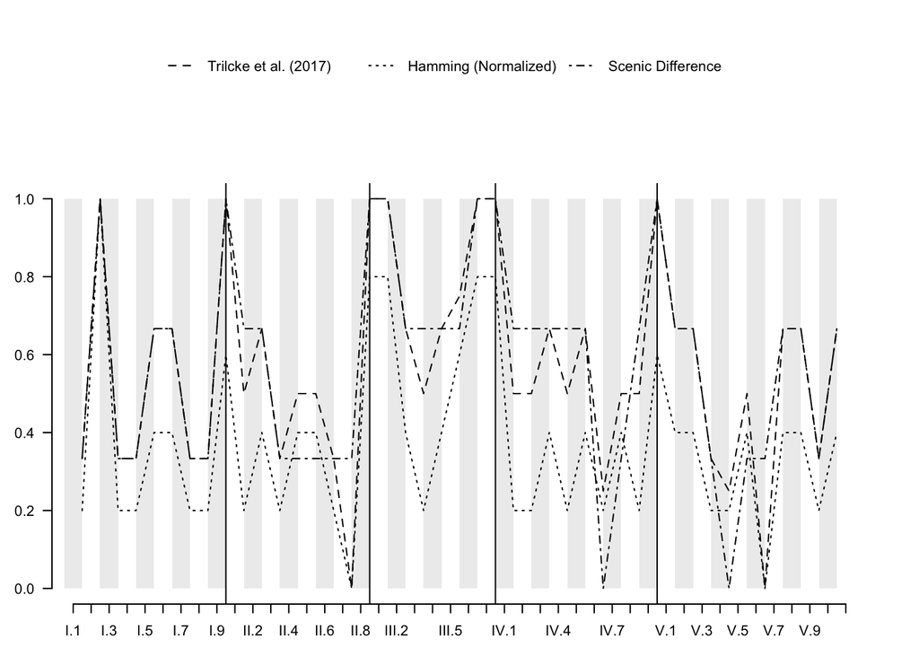

# About

This report has geen generated using the R package `DramaAnalysis` in version 2.0. The package is being developed [here](http://github.com/quadrama/DramaAnalysis), in the context of the project [QuaDramA](https://quadrama.github.io). Please report errors [here](https://github.com/quadrama/DramaAnalysis/issues), or contact me.